# Network Perception Analysis

Sima Najafzadehkhoei

2026-02-26

# Imaginary Network Motifs: Testing Systematic Perception Errors

People do not perceive social networks randomly—their errors follow systematic patterns (Tanaka & Vega Yon, 2023). This vignette demonstrates how to use `imaginarycss` to (1) compute observed imaginary-census motif counts, (2) generate a null distribution that preserves each perceiver’s tie-level accuracy, and (3) test which motif patterns are significantly elevated or reduced relative to chance.

## Setup

```r
library(imaginarycss)

# Load Krackhardt data
data(krackhardt_advice)
data(krackhardt_friendship)
data(krackhardt_friendship_perceptions)
data(krackhardt_advice_perceptions)

# Convert edge-list data frames to adjacency matrices
df_to_adjmat <- function(df) {
  n <- max(c(df$from, df$to))
  m <- matrix(0L, nrow = n, ncol = n)
  m[cbind(df$from, df$to)] <- df$value
  m
}

advice_matrix     <- df_to_adjmat(krackhardt_advice)
friendship_matrix <- df_to_adjmat(krackhardt_friendship)
```

## Data Overview

```r
n <- nrow(advice_matrix)

# Network summary
data.frame(
  Network    = c("Friendship", "Advice"),
  Edges      = c(sum(friendship_matrix), sum(advice_matrix)),
  Density    = round(c(
    sum(friendship_matrix) / (n * (n - 1)),
    sum(advice_matrix)     / (n * (n - 1))
  ), 3)
)
```

```
     Network Edges Density
1 Friendship   102   0.243
2     Advice   190   0.452
```

## Creating the CSS Graphs

Each graph bundles the true network (first element) with every individual’s perception.

```r
friendship_graph <- new_barry_graph(
  c(list(friendship_matrix), krackhardt_friendship_perceptions)
)
advice_graph <- new_barry_graph(
  c(list(advice_matrix), krackhardt_advice_perceptions)
)
```

## Observed Motif Counts

The imaginary census classifies every perceiver–dyad pair into one of ten categories. The `summary()` method aggregates counts across perceivers.

```r
friendship_observed <- count_imaginary_census(friendship_graph)
advice_observed     <- count_imaginary_census(advice_graph)

# Friendship motifs (top 6)
head(summary(friendship_observed))
```

```
                 Accurate null                  Accurate assym
                           2472                             529
Partial false positive (assym)   Partial false positive (null)
                            378                             276
                 Accurate full   Partial false negative (full)
                            269                             181
```

```r
# Advice motifs (top 6)
head(summary(advice_observed))
```

```
                Accurate assym                   Accurate null
                           1052                             992
                 Accurate full  Partial false negative (assym)
                            469                             463
Partial false positive (assym)   Partial false negative (full)
                            412                             395
```

## Null-Model Testing

The `test_imaginary_census()` function generates null CSS samples for each network. Each sample preserves every perceiver’s four accuracy rates (true-positive/true-negative for ego/alter dyads) but randomises which specific dyads are misperceived. It then computes z-scores and two-sided empirical p-values.

```r
set.seed(331)
friendship_test <- test_imaginary_census(friendship_graph, n_sim = 100)
advice_test     <- test_imaginary_census(advice_graph, n_sim = 100)
```

## Results

The `plot()` method for `imaginarycss_test` objects shows a horizontal barplot of z-scores for each motif. Motifs whose z-score exceeds the critical threshold (dashed red lines) are coloured steelblue; those within the expected range under the null model are shown in grey.

```r
# Print significant motifs
friendship_test
```

```
Imaginary-census significance test
  Simulations: 100  | Alpha: 0.05

Significant motifs:
                           motif observed z_score p_value
 Partial false positive (assym)       378   26.95       0
                 Accurate assym       529  -15.55       0
                  Accurate null      2472   14.57       0
  Partial false positive (null)       276  -13.56       0
                    Mixed assym        98   13.30       0
 Partial false negative (assym)       171   -5.64       0
 Complete false positive (null)         3   -5.36       0
```

```r
advice_test
```

```
Imaginary-census significance test
  Simulations: 100  | Alpha: 0.05

Significant motifs:
                           motif observed z_score p_value
 Partial false positive (assym)       412    7.87       0
                  Accurate null       992    7.38       0
  Partial false positive (null)       343   -6.12       0
                 Accurate assym      1052   -5.33       0
                    Mixed assym       173    3.59       0
 Complete false positive (null)        30   -3.58       0
```

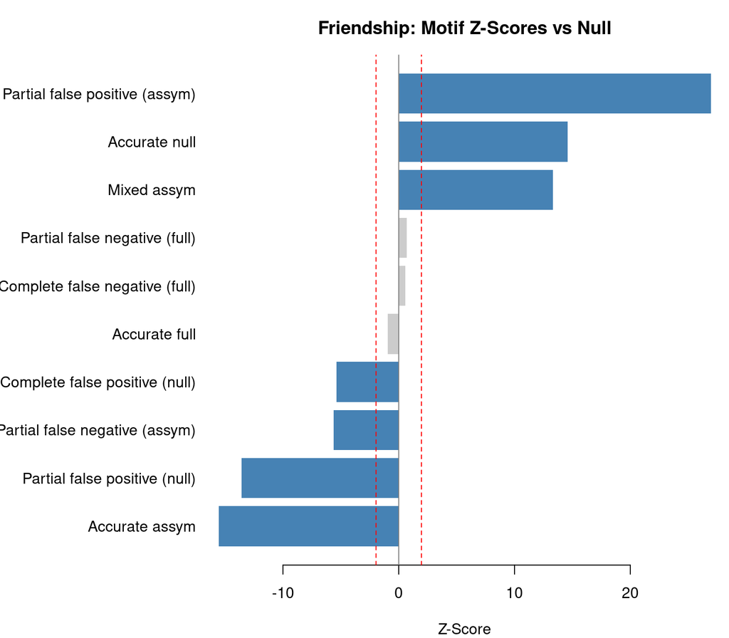

```r
# Visualise z-scores
plot(friendship_test, main = "Friendship: Motif Z-Scores vs Null")
```

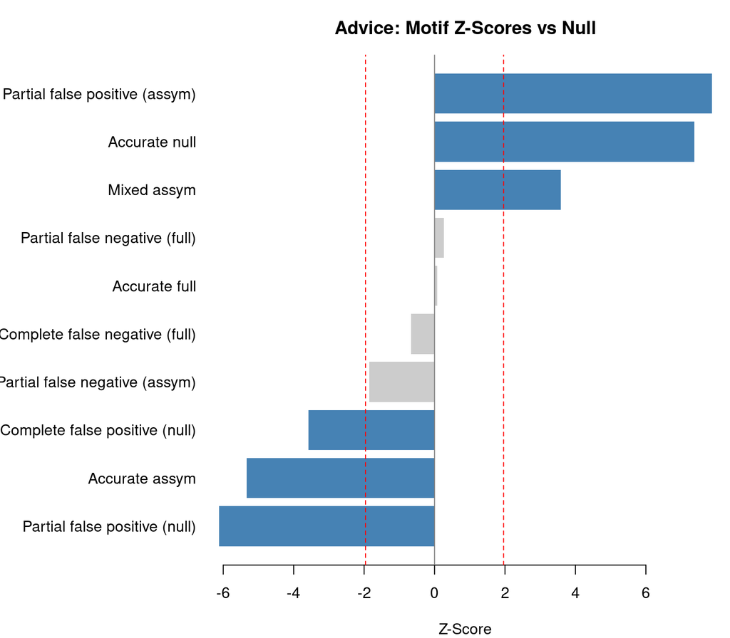

```r
plot(advice_test,     main = "Advice: Motif Z-Scores vs Null")
```

## Full Summary

The `summary()` method shows all motifs with their test statistics.

```r
summary(friendship_test)
```

```
Imaginary-census significance test
  Simulations: 100  | Alpha: 0.05
  Motifs tested: 10 | Significant: 7

                           motif observed null_mean null_sd z_score p_value
 Partial false positive (assym)       378     104.6   10.15   26.95    0.00
                 Accurate assym       529     790.0   16.78  -15.55    0.00
                  Accurate null      2472    2167.7   20.89   14.57    0.00
  Partial false positive (null)       276     546.3   19.94  -13.56    0.00
                    Mixed assym        98      33.3    4.86   13.30    0.00
 Partial false negative (assym)       171     248.0   13.65   -5.64    0.00
 Complete false positive (null)         3      37.0    6.34   -5.36    0.00
                  Accurate full       269     278.6   10.07   -0.95    0.34
  Partial false negative (full)       181     174.5    9.36    0.69    0.46
 Complete false negative (full)        33      29.9    5.46    0.57    0.62
 significant
        TRUE
        TRUE
        TRUE
        TRUE
        TRUE
        TRUE
        TRUE
       FALSE
       FALSE
       FALSE
```

## Tie-Level Accuracy

```r
friendship_acc <- tie_level_accuracy(friendship_graph)
advice_acc     <- tie_level_accuracy(advice_graph)

# Mean individual accuracy
data.frame(
  Network = c("Friendship", "Advice"),
  TP      = round(c(
    mean(friendship_acc$p_1_ego, na.rm = TRUE),
    mean(advice_acc$p_1_ego,     na.rm = TRUE)
  ), 3),
  TN      = round(c(
    mean(friendship_acc$p_0_ego, na.rm = TRUE),
    mean(advice_acc$p_0_ego,     na.rm = TRUE)
  ), 3)
)
```

```
     Network    TP    TN
1 Friendship 0.750 0.886
2     Advice 0.695 0.795
```

## Conclusion

By comparing observed motif counts against null distributions that preserve individual-level accuracy, the imaginary census reveals *which* perceptual errors are systematic rather than random. Elevated motifs indicate cognitive schemas (e.g., balance, reciprocity) that distort network perception beyond what individual accuracy rates alone would predict.